# Microfragmentation Immunity Data

Lou Schlecker & Rachel Wright

7/27/2021

# Immunity Analyses

We have immunity data for 96 fragments

```r
allData <- read.csv("allData.csv")
head(allData)
```

```
##   sam       date plate plateOrder geno size species airbrushVol       SA
## 1 A10  9/11/2016     3          8    A   10     cav         1.5 1.970588
## 2 A11 10/28/2016     4          1    A   11     cav         1.0 2.225490
## 3 A12  11/8/2016     7         10    A   12     cav         1.5 3.205882
## 4 A14  9/11/2016     3         10    A   14     cav         1.0 2.294118
## 5 A16  9/11/2016     3          7    A   16     cav         2.0 1.666667
## 6 A17  11/8/2016     7          9    A   17     cav         1.0 1.500000
##   prot.10uL.     protN        cat          po         ppo        pox       catN
## 1  0.7306818 0.5561906 -0.5709343 0.006633333 0.002455556 0.01979412 -1.0265083
## 2  1.1814684 0.5308801 -0.6223099 0.014383333 0.012577778 0.16223529 -1.1722231
## 3  1.9825838 0.9276309 -1.0581274 0.027200000 0.026216667 0.04929412 -1.1406771
## 4  0.9888109 0.4310201 -0.4290657 0.006755556 0.002666667 0.05255882 -0.9954656
## 5  0.7255702 0.8706843 -0.5363322 0.003555556 0.001477778 0.01555882 -0.6159893
## 6  1.0289285 0.6859523 -0.3643114 0.011533333 0.008641667 0.05952941 -0.5311031
##    abs.catN         poN        ppoN       poxN
## 1 1.0265083 0.011926367 0.004414953 0.03558873
## 2 1.1722231 0.027093375 0.023692314 0.30559687
## 3 1.1406771 0.029322006 0.028261958 0.05313979
## 4 0.9954656 0.015673410 0.006186872 0.12194052
## 5 0.6159893 0.004083633 0.001697260 0.01786965
## 6 0.5311031 0.016813608 0.012598057 0.08678360
```

Combine immune data with the growth data

```r
growthData <- read.csv("growthData.csv")
combinedData <- merge(allData, growthData, by=c("sam","geno"))
head(combinedData)
```

```
##   sam geno       date plate plateOrder size species airbrushVol       SA
## 1 A10    A  9/11/2016     3          8   10     cav         1.5 1.970588
## 2 A11    A 10/28/2016     4          1   11     cav         1.0 2.225490
## 3 A12    A  11/8/2016     7         10   12     cav         1.5 3.205882
## 4 A14    A  9/11/2016     3         10   14     cav         1.0 2.294118
## 5 A16    A  9/11/2016     3          7   16     cav         2.0 1.666667
## 6 A17    A  11/8/2016     7          9   17     cav         1.0 1.500000
##   prot.10uL.     protN        cat          po         ppo        pox       catN
## 1  0.7306818 0.5561906 -0.5709343 0.006633333 0.002455556 0.01979412 -1.0265083
## 2  1.1814684 0.5308801 -0.6223099 0.014383333 0.012577778 0.16223529 -1.1722231
## 3  1.9825838 0.9276309 -1.0581274 0.027200000 0.026216667 0.04929412 -1.1406771
## 4  0.9888109 0.4310201 -0.4290657 0.006755556 0.002666667 0.05255882 -0.9954656
## 5  0.7255702 0.8706843 -0.5363322 0.003555556 0.001477778 0.01555882 -0.6159893
## 6  1.0289285 0.6859523 -0.3643114 0.011533333 0.008641667 0.05952941 -0.5311031
##    abs.catN         poN        ppoN       poxN rankbyInitialWeight
```

[output cut: 27 more lines]

Combine Genets X and V, which we know from sequence data are clones Rename them both “U”

```r
combinedData$geno <- gsub("X|V", "U", combinedData$geno)
combinedData$geno
```

```
##  [1] "A" "A" "A" "A" "A" "A" "A" "A" "A" "A" "A" "A" "A" "B" "B" "B" "B" "B" "B"
## [20] "B" "B" "B" "C" "C" "C" "C" "C" "C" "C" "C" "D" "D" "D" "D" "D" "D" "D" "E"
## [39] "E" "E" "E" "E" "E" "E" "E" "E" "E" "U" "U" "U" "U" "U" "U" "U" "U" "U" "U"
## [58] "W" "W" "W" "W" "W" "W" "W" "W" "W" "U" "U" "U" "U" "U" "U" "U" "U" "U" "U"
## [77] "U" "U" "U" "Y" "Y" "Y" "Y" "Y" "Y" "Y" "Y" "Y" "Y" "Z" "Z" "Z" "Z" "Z" "Z"
## [96] "Z"
```

Explore immune data

prot.10uL. = protein concentration in 10 µL sample included in protein assay (mg/mL)

protN = total protein normalized to surface area (mg) (protein concentration in 10 µL sample (mg/mL) * airbrush volume (mL)) / surface area (cm2) final units = mg/cm2

ppo (total phenoloxidase potential) and po (active phenoloxidase) = ∆A490 / min pox (peroxidase) = ∆A470 / min cat (catalase) = ∆H2O2 / min

ppoN, poN, poxN, and catN = normalized to total protein final units = change in absorbance / min per mg protein

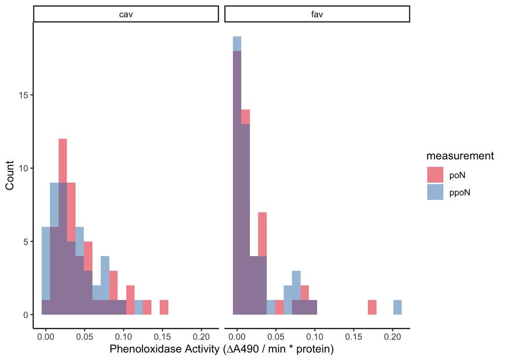

```r
combinedData %>% select(poN, ppoN, species) %>%
  pivot_longer(cols = c(poN, ppoN),
               names_to = "measurement",
               values_to = "value") %>%
  ggplot(aes(x = value, fill = measurement)) +
  facet_grid(~ species) +
  ylab("Count") +
  xlab("Phenoloxidase Activity (∆A490 / min * protein)") +
  geom_histogram(position = "identity", alpha = 0.5, bins = 20) +
  theme_classic() +
  scale_color_manual(name = "Measurement",
                    labels = c("Active PO", "Total Potential PO"))+
  scale_fill_brewer(palette = "Set1")
```

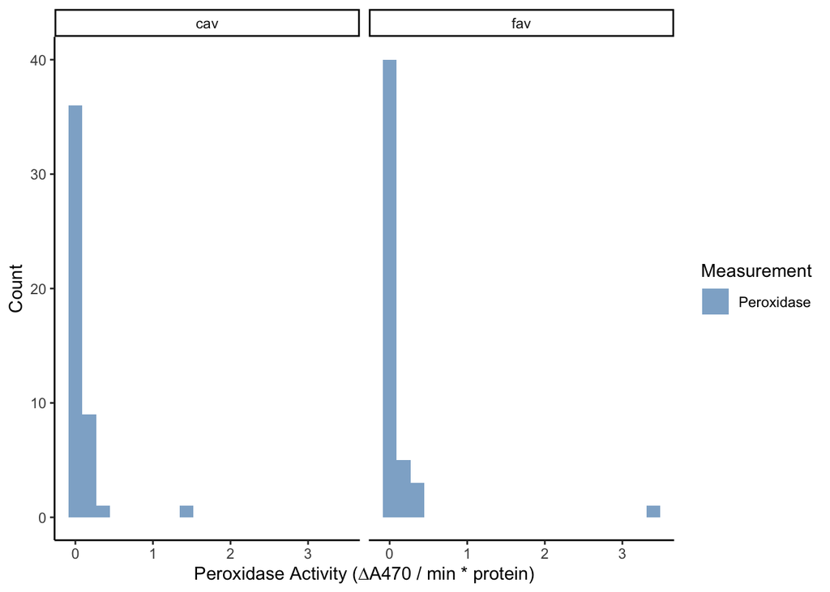

```r
combinedData %>% select(poxN, species) %>%
  pivot_longer(cols = c(poxN),
               names_to = "measurement",
               values_to = "value") %>%
  ggplot(aes(x = value, fill = measurement)) +
  facet_grid(~ species) +
  ylab("Count") +
  xlab("Peroxidase Activity (∆A470 / min * protein)") +
  geom_histogram(position = "identity", alpha = 0.65, bins = 20) +
  theme_classic() +
  scale_fill_manual(values=c("steelblue"),
                      name = "Measurement",
                    labels = c("Peroxidase"))
```

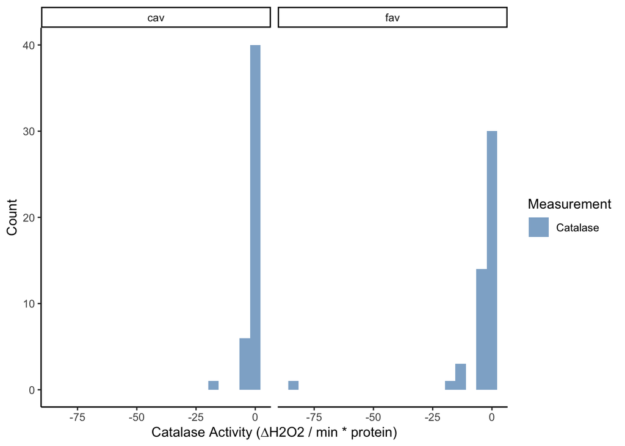

```r
combinedData %>% select(catN, species) %>%
  pivot_longer(cols = c(catN),
               names_to = "measurement",
               values_to = "value") %>%
  ggplot(aes(x = value, fill = measurement)) +
  facet_grid(~ species) +
  ylab("Count") +
  xlab("Catalase Activity (∆H2O2 / min * protein)") +
  geom_histogram(position = "identity", alpha = 0.65, bins = 20) +
  theme_classic() +
  scale_fill_manual(values=c("steelblue"),
                      name = "Measurement",
                    labels = c("Catalase"))
```

Catalase

The values for catalase are negative because H2O2 is being consumed by catalase. Multiply by -1 to convert to “positive” values for easier interpretation.

```r
combinedData <- combinedData %>% mutate(catNP = catN*-1)
```

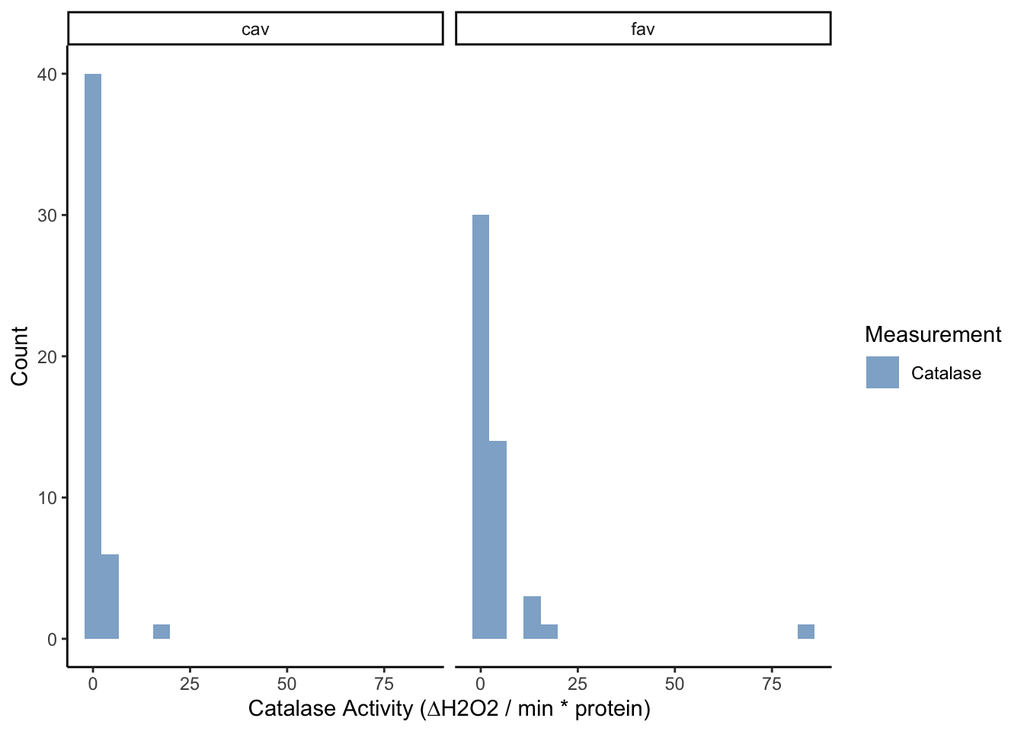

```r
combinedData %>% select(catNP, species) %>%
  pivot_longer(cols = c(catNP),
               names_to = "measurement",
               values_to = "value") %>%
  ggplot(aes(x = value, fill = measurement)) +
  facet_grid(~ species) +
  ylab("Count") +
  xlab("Catalase Activity (∆H2O2 / min * protein)") +
  geom_histogram(position = "identity", alpha = 0.65, bins = 20) +
  theme_classic() +
  scale_fill_manual(values=c("steelblue"),
                      name = "Measurement",
                    labels = c("Catalase"))
```

Summarize all of the data before outliers are removed

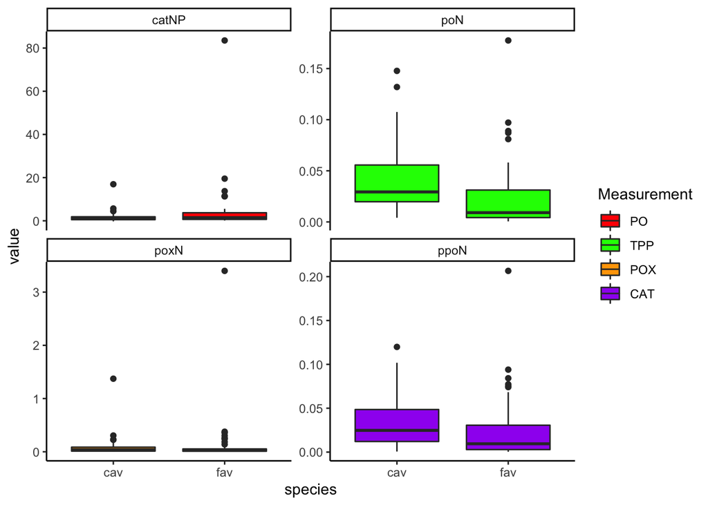

```r
boxplot.before.outliers <- combinedData %>% select(poN, ppoN, poxN, catNP, species) %>%
  pivot_longer(cols = c(poN, ppoN, poxN, catNP),
               names_to = "measurement",
               values_to = "value") %>%
  ggplot(aes(x = species, y = value, fill = measurement)) +
  facet_wrap(~ measurement, scales = "free_y") +
  geom_boxplot() +
  theme_classic() +
  scale_fill_manual(values=c("red", "green", "orange", "purple"),
                      name = "Measurement",
                    labels = c("PO", "TPP", "POX", "CAT"))
boxplot.before.outliers
```

Remove outliers

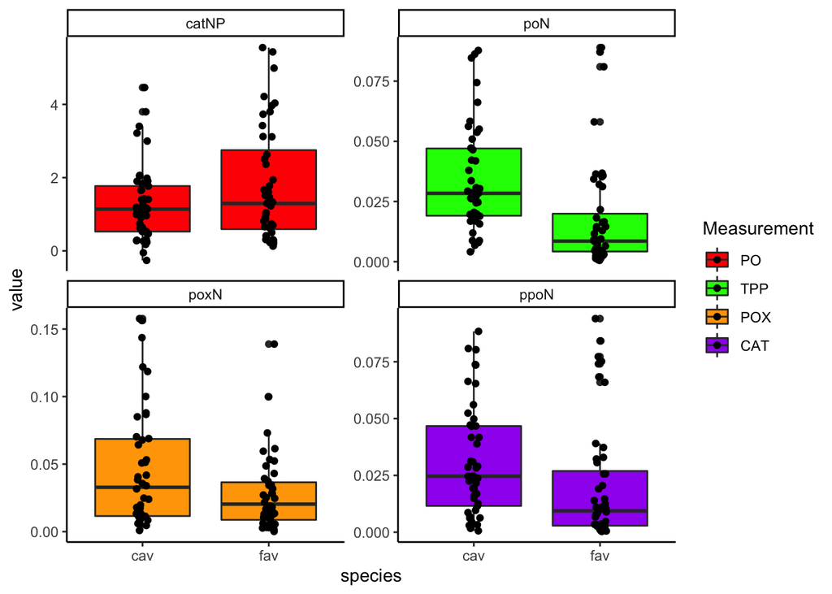

```r
box.cat <- boxplot(combinedData$catNP, plot = FALSE)
combinedData$catNP[which(combinedData$catNP %in% box.cat$out)] <- "NA"
combinedData$catNP <- as.numeric(as.character(combinedData$catNP))
box.pox <- boxplot(combinedData$poxN, plot = FALSE)
combinedData$poxN[which(combinedData$poxN %in% box.pox$out)] <- "NA"
combinedData$poxN <- as.numeric(as.character(combinedData$poxN))
box.po <- boxplot(combinedData$poN, plot = FALSE)
combinedData$poN[which(combinedData$poN %in% box.po$out)] <- "NA"
combinedData$poN <- as.numeric(as.character(combinedData$poN))
box.ppo <- boxplot(combinedData$ppoN, plot = FALSE)
combinedData$ppoN[which(combinedData$ppoN %in% box.ppo$out)] <- "NA"
combinedData$ppoN <- as.numeric(as.character(combinedData$ppoN))
boxplot.removed.outliers <- combinedData %>% select(poN, ppoN, poxN, catNP, species) %>%
  pivot_longer(cols = c(poN, ppoN, poxN, catNP),
               names_to = "measurement",
               values_to = "value") %>%
  ggplot(aes(x = species, y = value, fill = measurement)) +
  facet_wrap(~ measurement, scales = "free_y") +
  geom_boxplot() +
  geom_jitter(width=0.05) +
  theme_classic() +
  scale_fill_manual(values=c("red", "green", "orange", "purple"),
                      name = "Measurement",
                    labels = c("PO", "TPP", "POX", "CAT"))
boxplot.removed.outliers
```

Save/Load

```r
save(combinedData, file="immune_growth_data.RData")
load("immune_growth_data.RData")
```

# Investigate patterns between initial size and immune activity

Phenoloxidase ~ Initial Weight

```r
set.seed(1)
mcmc.PO.wt.species.raw <- MCMCglmm(poN~WT1*species,
                           random=~geno,
                           data=combinedData)
```

[output not shown]

```r
summary(mcmc.PO.wt.species.raw)
```

```
##
##  Iterations = 3001:12991
##  Thinning interval  = 10
##  Sample size  = 1000
##
##  DIC: -464.6945
##
##  G-structure:  ~geno
##
##      post.mean  l-95% CI u-95% CI eff.samp
## geno 0.0002975 3.733e-05 0.000718     1000
##
##  R-structure:  ~units
##
##       post.mean  l-95% CI  u-95% CI eff.samp
## units 0.0002843 0.0002086 0.0003843     1000
##
##  Location effects: poN ~ WT1 * species
##
##                post.mean  l-95% CI  u-95% CI eff.samp  pMCMC
## (Intercept)    -0.014509 -0.045214  0.018359     1207  0.396
## WT1             0.003447  0.001648  0.005422     1234 <0.001 ***
## speciesfav      0.013826 -0.027564  0.060999     1216  0.534
## WT1:speciesfav -0.001854 -0.004165  0.001076     1329  0.166
## ---
## Signif. codes:  0 '***' 0.001 '**' 0.01 '*' 0.05 '.' 0.1 ' ' 1
```

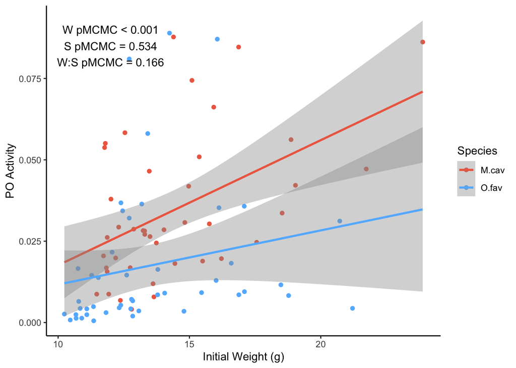

```r
plotPO_WT1_raw <- combinedData %>%
  ggplot(aes(x=WT1, y=poN, color=species))+
  geom_point()+
  geom_smooth(method=lm, se=T, fullrange=TRUE)+
  theme_classic()+
  ylab("PO Activity")+
  xlab("Initial Weight (g)")+
  annotate("text", x = 12, y = 0.09, label = "W pMCMC < 0.001")+
  annotate("text", x = 12, y = 0.085, label = "S pMCMC = 0.534")+
  annotate("text", x = 12, y = 0.08, label = "W:S pMCMC = 0.166")+
  scale_color_manual(values = c("coral2", "steelblue1"),
                       name = "Species",
                       labels = c("M.cav", "O.fav"))
plotPO_WT1_raw
```

```r
set.seed(1)
mcmc.PO.wt.species <- MCMCglmm(log(poN,2)~log(WT1,2)*species,
                           random=~geno,
                           data=combinedData)
```

[output not shown]

```r
summary(mcmc.PO.wt.species)
```

```
##
##  Iterations = 3001:12991
##  Thinning interval  = 10
##  Sample size  = 1000
##
##  DIC: 278.8409
##
##  G-structure:  ~geno
##
##      post.mean l-95% CI u-95% CI eff.samp
## geno     1.126  0.09263    2.675     1000
##
##  R-structure:  ~units
##
##       post.mean l-95% CI u-95% CI eff.samp
## units     1.209   0.8688    1.615     1000
##
##  Location effects: log(poN, 2) ~ log(WT1, 2) * species
##
##                        post.mean l-95% CI u-95% CI eff.samp  pMCMC
## (Intercept)             -11.8084 -16.9759  -6.5271     1257 <0.001 ***
## log(WT1, 2)               1.7393   0.4270   3.1093     1246  0.012 *
## speciesfav               -3.9029 -11.3960   2.7401     1407  0.258
## log(WT1, 2):speciesfav    0.7176  -0.9173   2.6816     1339  0.430
## ---
## Signif. codes:  0 '***' 0.001 '**' 0.01 '*' 0.05 '.' 0.1 ' ' 1
```

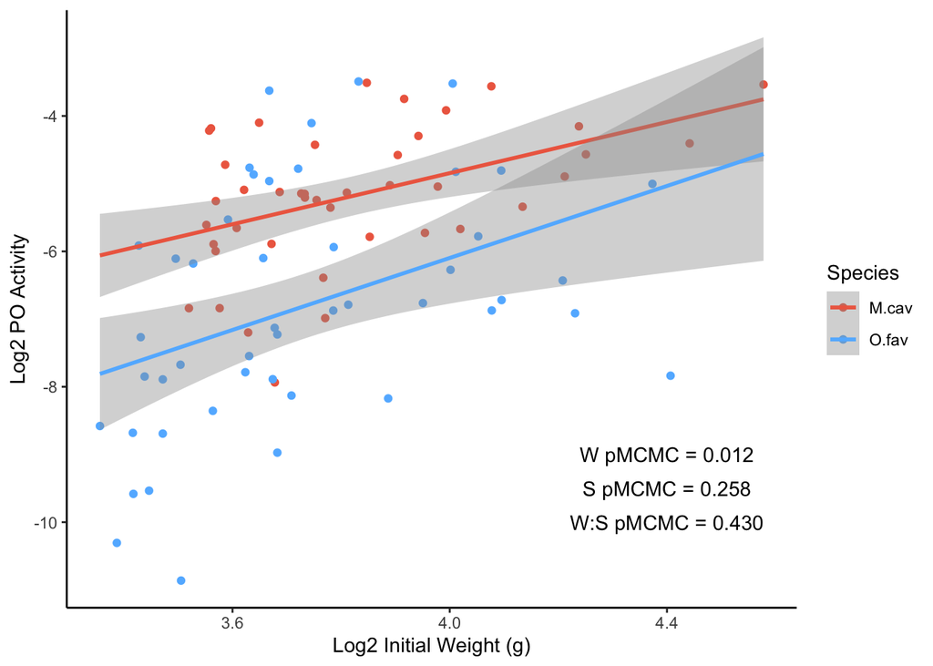

```r
plotPO_WT1 <- combinedData %>%
  ggplot(aes(x=log(WT1,2), y=log(poN,2), color=species))+
  geom_point()+
  geom_smooth(method=lm, se=T, fullrange=TRUE)+
  theme_classic()+
  ylab("Log2 PO Activity")+
  xlab("Log2 Initial Weight (g)")+
  annotate("text", x = 4.4, y = -9, label = "W pMCMC = 0.012")+
  annotate("text", x = 4.4, y = -9.5, label = "S pMCMC = 0.258")+
  annotate("text", x = 4.4, y = -10, label = "W:S pMCMC = 0.430")+
  scale_color_manual(values = c("coral2", "steelblue1"),
                       name = "Species",
                       labels = c("M.cav", "O.fav"))
plotPO_WT1
```

Total phenoloxidase potential ~ Initial Weight

```r
set.seed(1)
mcmc.PPO.wt.species.raw <- MCMCglmm(ppoN~WT1*species,
                           random=~geno,
                           data=combinedData)
```

[output not shown]

```r
summary(mcmc.PPO.wt.species.raw)
```

```
##
##  Iterations = 3001:12991
##  Thinning interval  = 10
##  Sample size  = 1000
##
##  DIC: -450.4433
##
##  G-structure:  ~geno
##
##      post.mean l-95% CI  u-95% CI eff.samp
## geno   0.00021 8.94e-08 0.0005577     1000
##
##  R-structure:  ~units
##
##       post.mean  l-95% CI  u-95% CI eff.samp
## units 0.0004186 0.0002972 0.0005528     1000
##
##  Location effects: ppoN ~ WT1 * species
##
##                 post.mean   l-95% CI   u-95% CI eff.samp  pMCMC
## (Intercept)    -0.0335409 -0.0659364 -0.0012914     1000  0.046 *
## WT1             0.0044189  0.0025807  0.0062789     1358 <0.001 ***
## speciesfav      0.0290324 -0.0133364  0.0748515     1159  0.234
## WT1:speciesfav -0.0024740 -0.0051610  0.0003639     1279  0.094 .
## ---
## Signif. codes:  0 '***' 0.001 '**' 0.01 '*' 0.05 '.' 0.1 ' ' 1
```

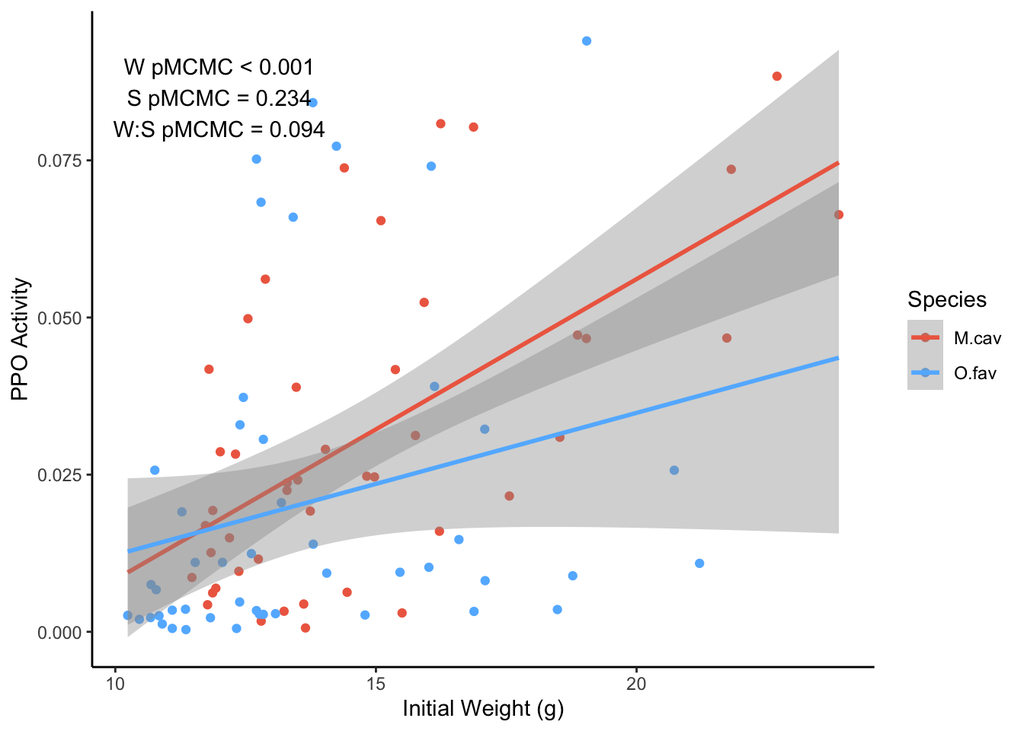

```r
plotPPO_WT1_raw <- combinedData %>%
  ggplot(aes(x=WT1, y=ppoN, color=species))+
  geom_point()+
  geom_smooth(method=lm, se=T, fullrange=TRUE)+
  theme_classic()+
  ylab("PPO Activity")+
  xlab("Initial Weight (g)")+
  annotate("text", x = 12, y = 0.09, label = "W pMCMC < 0.001")+
  annotate("text", x = 12, y = 0.085, label = "S pMCMC = 0.234")+
  annotate("text", x = 12, y = 0.08, label = "W:S pMCMC = 0.094")+
  scale_color_manual(values = c("coral2", "steelblue1"),
                       name = "Species",
                       labels = c("M.cav", "O.fav"))
plotPPO_WT1_raw
```

```r
set.seed(1)
mcmc.PPO.wt.species <- MCMCglmm(log(ppoN,2)~log(WT1,2)*species,
                           random=~geno,
                           data=combinedData)
```

[output not shown]

```r
summary(mcmc.PPO.wt.species)
```

```
##
##  Iterations = 3001:12991
##  Thinning interval  = 10
##  Sample size  = 1000
##
##  DIC: 358.1602
##
##  G-structure:  ~geno
##
##      post.mean  l-95% CI u-95% CI eff.samp
## geno    0.8312 4.467e-05    2.314    890.1
##
##  R-structure:  ~units
##
##       post.mean l-95% CI u-95% CI eff.samp
## units     2.511    1.764    3.356    808.2
##
##  Location effects: log(ppoN, 2) ~ log(WT1, 2) * species
##
##                        post.mean  l-95% CI  u-95% CI eff.samp  pMCMC
## (Intercept)            -15.40741 -21.17333  -8.68273     1000 <0.001 ***
## log(WT1, 2)              2.54785   0.89539   4.13281     1350  0.006 **
## speciesfav              -0.58137  -9.09293   8.29117     1301  0.888
## log(WT1, 2):speciesfav  -0.05842  -2.16679   2.35240     1286  0.942
## ---
## Signif. codes:  0 '***' 0.001 '**' 0.01 '*' 0.05 '.' 0.1 ' ' 1
```

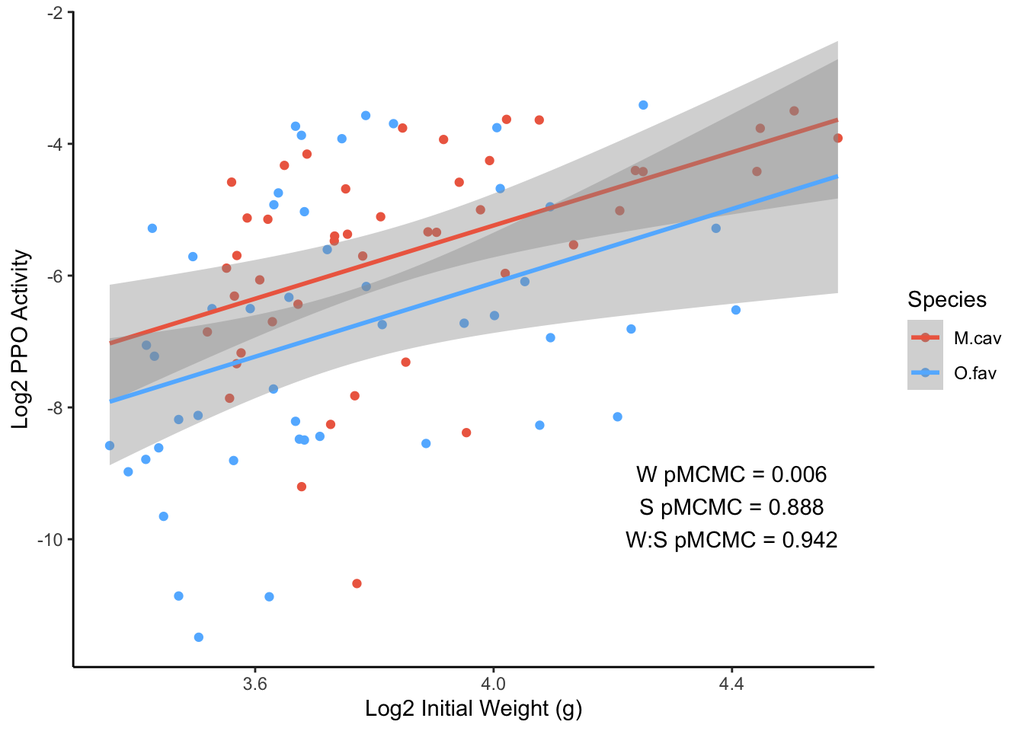

```r
plotPPO_WT1 <- combinedData %>%
  ggplot(aes(x=log(WT1,2), y=log(ppoN,2), color=species))+
  geom_point()+
  geom_smooth(method=lm, se=T, fullrange=TRUE)+
  theme_classic()+
  ylab("Log2 PPO Activity")+
  xlab("Log2 Initial Weight (g)")+
  annotate("text", x = 4.4, y = -9, label = "W pMCMC = 0.006")+
  annotate("text", x = 4.4, y = -9.5, label = "S pMCMC = 0.888")+
  annotate("text", x = 4.4, y = -10, label = "W:S pMCMC = 0.942")+
  scale_color_manual(values = c("coral2", "steelblue1"),
                       name = "Species",
                       labels = c("M.cav", "O.fav"))
plotPPO_WT1
```

Peroxidase ~ Initial Weight

```r
set.seed(1)
mcmc.POX.wt.species.raw <- MCMCglmm(poxN~WT1*species,
                           random=~geno,
                           data=combinedData)
```

[output not shown]

```r
summary(mcmc.POX.wt.species.raw)
```

```
##
##  Iterations = 3001:12991
##  Thinning interval  = 10
##  Sample size  = 1000
##
##  DIC: -328.8378
##
##  G-structure:  ~geno
##
##      post.mean  l-95% CI u-95% CI eff.samp
## geno 0.0004167 4.902e-17 0.001235     89.9
##
##  R-structure:  ~units
##
##       post.mean  l-95% CI u-95% CI eff.samp
## units  0.001051 0.0006889 0.001445    100.4
##
##  Location effects: poxN ~ WT1 * species
##
##                post.mean  l-95% CI  u-95% CI eff.samp  pMCMC
## (Intercept)    -0.050638 -0.108251  0.014292    739.1  0.134
## WT1             0.006598  0.002405  0.010382    773.0 <0.001 ***
## speciesfav      0.012797 -0.072249  0.090183    980.0  0.754
## WT1:speciesfav -0.001752 -0.007496  0.003339    989.2  0.532
## ---
## Signif. codes:  0 '***' 0.001 '**' 0.01 '*' 0.05 '.' 0.1 ' ' 1
```

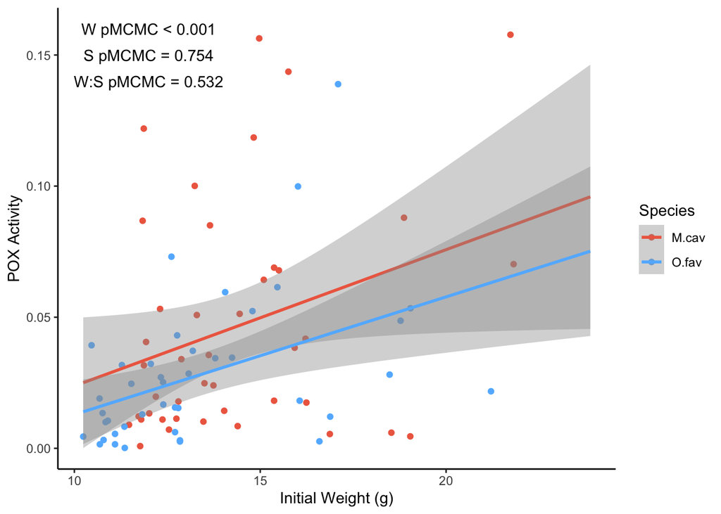

```r
plotPOX_WT1_raw <- combinedData %>%
  ggplot(aes(x=WT1, y=poxN, color=species))+
  geom_point()+
  geom_smooth(method=lm, se=T, fullrange=TRUE)+
  theme_classic()+
  ylab("POX Activity")+
  xlab("Initial Weight (g)")+
  annotate("text", x = 12, y = 0.16, label = "W pMCMC < 0.001")+
  annotate("text", x = 12, y = 0.15, label = "S pMCMC = 0.754")+
  annotate("text", x = 12, y = 0.14, label = "W:S pMCMC = 0.532")+
  scale_color_manual(values = c("coral2", "steelblue1"),
                       name = "Species",
                       labels = c("M.cav", "O.fav"))
plotPOX_WT1_raw
```

```r
set.seed(1)
mcmc.POX.wt.species <- MCMCglmm(log(poxN,2)~log(WT1,2)*species,
                           random=~geno,
                           data=combinedData)
```

[output not shown]

```r
summary(mcmc.POX.wt.species)
```

```
##
##  Iterations = 3001:12991
##  Thinning interval  = 10
##  Sample size  = 1000
##
##  DIC: 333.5126
##
##  G-structure:  ~geno
##
##      post.mean l-95% CI u-95% CI eff.samp
## geno   0.07706 4.82e-17   0.5135    74.63
##
##  R-structure:  ~units
##
##       post.mean l-95% CI u-95% CI eff.samp
## units     2.945    2.061    3.889     1000
##
##  Location effects: log(poxN, 2) ~ log(WT1, 2) * species
##
##                        post.mean l-95% CI u-95% CI eff.samp pMCMC
## (Intercept)             -11.6859 -20.0154  -3.5140     1000 0.010 **
## log(WT1, 2)               1.6986  -0.5529   3.8216     1000 0.138
## speciesfav               -5.5321 -17.3358   4.6247     1228 0.304
## log(WT1, 2):speciesfav    1.3134  -1.3691   4.4021     1117 0.346
## ---
## Signif. codes:  0 '***' 0.001 '**' 0.01 '*' 0.05 '.' 0.1 ' ' 1
```

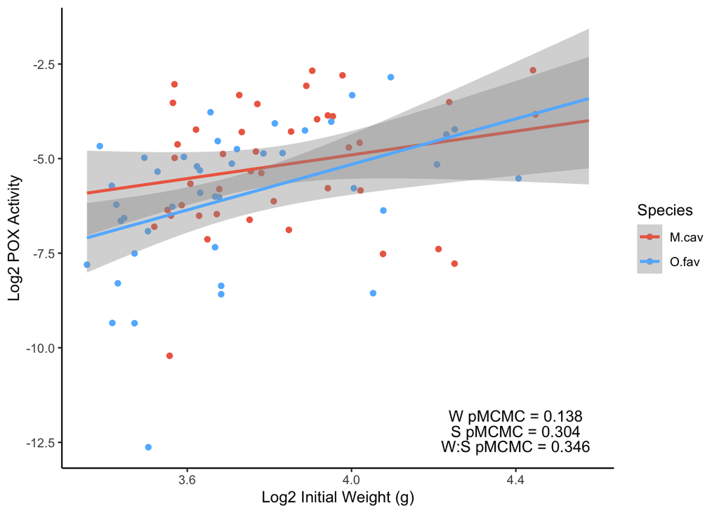

```r
plotPOX_WT1 <- combinedData %>%
  ggplot(aes(x=log(WT1,2), y=log(poxN,2), color=species))+
  geom_point()+
  geom_smooth(method=lm, se=T, fullrange=TRUE)+
  theme_classic()+
  ylab("Log2 POX Activity")+
  xlab("Log2 Initial Weight (g)")+
  annotate("text", x = 4.4, y = -11.8, label = "W pMCMC = 0.138")+
  annotate("text", x = 4.4, y = -12.2, label = "S pMCMC = 0.304")+
  annotate("text", x = 4.4, y = -12.6, label = "W:S pMCMC = 0.346")+
  scale_color_manual(values = c("coral2", "steelblue1"),
                       name = "Species",
                       labels = c("M.cav", "O.fav"))
plotPOX_WT1
```

Catalase ~ Initial Weight

```r
set.seed(1)
mcmc.CAT.wt.species.raw <- MCMCglmm(catNP~WT1*species,
                           random=~geno,
                           data=combinedData)
```

[output not shown]

```r
summary(mcmc.CAT.wt.species.raw)
```

```
##
##  Iterations = 3001:12991
##  Thinning interval  = 10
##  Sample size  = 1000
##
##  DIC: 294.1255
##
##  G-structure:  ~geno
##
##      post.mean l-95% CI u-95% CI eff.samp
## geno  0.003999 4.82e-17    0.022    137.7
##
##  R-structure:  ~units
##
##       post.mean l-95% CI u-95% CI eff.samp
## units     1.532    1.106    2.019     1000
##
##  Location effects: catNP ~ WT1 * species
##
##                post.mean l-95% CI u-95% CI eff.samp  pMCMC
## (Intercept)     -2.03762 -3.74694 -0.39633     1360  0.024 *
## WT1              0.22418  0.11410  0.33305     1133 <0.001 ***
## speciesfav       2.74071  0.32378  5.22573     1101  0.040 *
## WT1:speciesfav  -0.14384 -0.30944  0.03083     1199  0.110
## ---
## Signif. codes:  0 '***' 0.001 '**' 0.01 '*' 0.05 '.' 0.1 ' ' 1
```

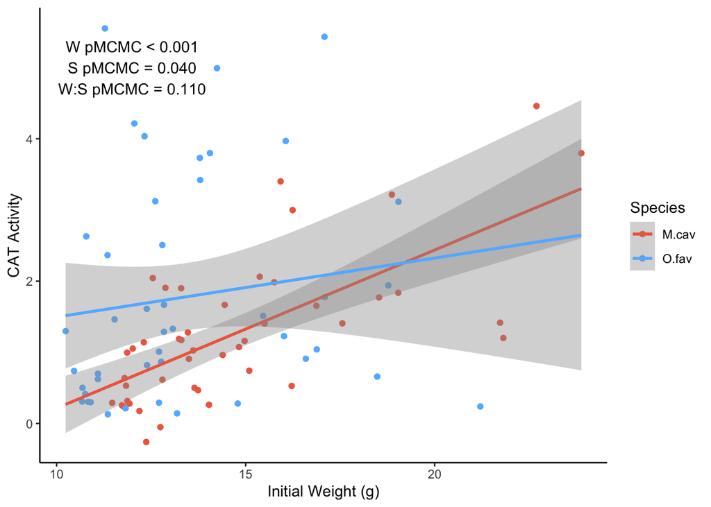

```r
plotCAT_WT1_raw <- combinedData %>%
  ggplot(aes(x=WT1, y=catNP, color=species))+
  geom_point()+
  geom_smooth(method=lm, se=T, fullrange=TRUE)+
  theme_classic()+
  ylab("CAT Activity")+
  xlab("Initial Weight (g)")+
  annotate("text", x = 12, y = 5.3, label = "W pMCMC < 0.001")+
  annotate("text", x = 12, y = 5, label = "S pMCMC = 0.040")+
  annotate("text", x = 12, y = 4.7, label = "W:S pMCMC = 0.110")+
  scale_color_manual(values = c("coral2", "steelblue1"),
                       name = "Species",
                       labels = c("M.cav", "O.fav"))
plotCAT_WT1_raw
```

```r
set.seed(1)
mcmc.CAT.wt.species <- MCMCglmm(log(catNP,2)~log(WT1,2)*species,
                           random=~geno,
                           data=combinedData)
```

[output not shown]

```r
summary(mcmc.CAT.wt.species)
```

```
##
##  Iterations = 3001:12991
##  Thinning interval  = 10
##  Sample size  = 1000
##
##  DIC: 290.9956
##
##  G-structure:  ~geno
##
##      post.mean l-95% CI u-95% CI eff.samp
## geno  0.008656 4.82e-17  0.04194    173.8
##
##  R-structure:  ~units
##
##       post.mean l-95% CI u-95% CI eff.samp
## units      1.59    1.133     2.09     1000
##
##  Location effects: log(catNP, 2) ~ log(WT1, 2) * species
##
##                        post.mean l-95% CI u-95% CI eff.samp  pMCMC
## (Intercept)             -10.4075 -15.2966  -5.4493     1000 <0.001 ***
## log(WT1, 2)               2.6945   1.4266   3.9905     1000 <0.001 ***
## speciesfav                6.6432  -0.8197  13.2393     1217  0.080 .
## log(WT1, 2):speciesfav   -1.6339  -3.4969   0.1811     1216  0.086 .
## ---
## Signif. codes:  0 '***' 0.001 '**' 0.01 '*' 0.05 '.' 0.1 ' ' 1
```

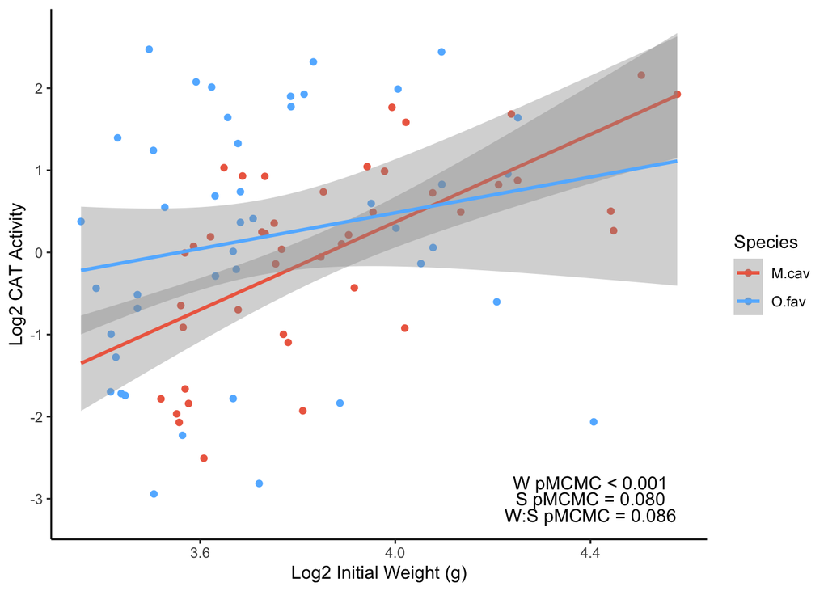

```r
plotCAT_WT1 <- combinedData %>%
  ggplot(aes(x=log(WT1,2), y=log(catNP,2), color=species))+
  geom_point()+
  geom_smooth(method=lm, se=T, fullrange=TRUE)+
  theme_classic()+
  ylab("Log2 CAT Activity")+
  xlab("Log2 Initial Weight (g)")+
  annotate("text", x = 4.4, y = -2.8, label = "W pMCMC < 0.001")+
  annotate("text", x = 4.4, y = -3, label = "S pMCMC = 0.080")+
  annotate("text", x = 4.4, y = -3.2, label = "W:S pMCMC = 0.086")+
  scale_color_manual(values = c("coral2", "steelblue1"),
                       name = "Species",
                       labels = c("M.cav", "O.fav"))
plotCAT_WT1
```